# QuEST coding workshop day 2: tidyverse introduction

### Going further

- A deeper summary of tidygraph’s features can be found [here](https://www.data-imaginist.com/2017/introducing-tidygraph)
- Something we didn’t get into is the *layout* of graphs, and a number of algorithms exist for deciding where to arrange nodes in a plot. In ggraph you can specify which layout you want with `ggraph(graph, layout = ...)`. Many other ways beyond the “ball and stick” visualization for graphs are also available; see [here](https://www.data-imaginist.com/2017/ggraph-introduction-layouts/) for a good intro.
- tidygraph borrows heavily from another network analysis project called `igraph`. While igraph itself is implemented in the C language for speed, an R package also exists. Anything you can do in R’s igraph can be done in tidygraph, and personally I find the igraph package a bit outdated, but if you don’t like the “two-tibble” approach know that another option exists.

## Bonus: deSolve and simulating data over multiple parameters

You’ve seen how to do some work with systems of differential equations (compartmental models) on paper, but how can we see how these systems evolve over time as a whole? For that, we usually need a computer to help, using *numerical integration*.

In MOCS, you will learn much more about numerical integration and even write your own algorithms for it. However, there is also an R package for this using state-of-the-art algorithms, called `deSolve`.

```r
library(deSolve)
```

The main function of interest here is `ode` (for ordinary differential equation), which will simulate a system given a list derivatives and an initial state. We specify a compartmental model like this:

```r
SIS_system <- function(t, state, parameters) {
  with(as.list(c(state, parameters)), { # add names to environment
    dI <- beta * (1 - I) * I - alpha * I # derivative for I compartment
    return(list(dI)) # always must return a list of all derivatives
  })
}
```

and simulate this system with $\beta = 0.3$, $\alpha = 0.1$, and $I_0 = 0.1$:

```r
sis_res <- ode(
  y = c(I = 0.1), # named vector of initial states
  times = 0:50, # integrate the system from t=0 to 50
  func = SIS_system, # where to get the derivatives for updating
  parms = c(alpha = 0.1, beta = 0.3) # fixed parameters
)
```

`ode` returns a matrix, with `time` as the first column and the state variables for each $t$ as the following columns:

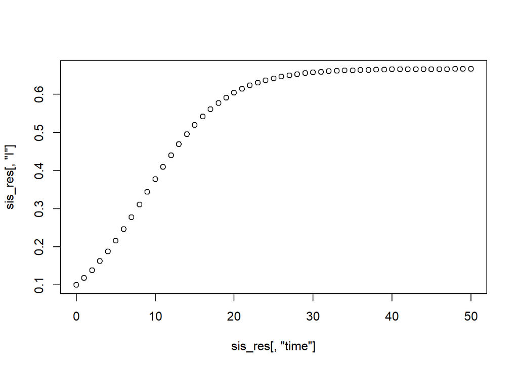

```r
plot(sis_res[,'time'], sis_res[,'I'])
```

As we can see, $I$ is approaching the expected steady-state $1 - \alpha / \beta$.

### Examining the reproductive number

To check our derivation of $R_0$, we will perform a *sensitivity analysis*, where we basically test our model over a wide combination of variables. Since we only have two parameters and a very simple model, this can be done with a simple grid over $\alpha$ and $\beta$:

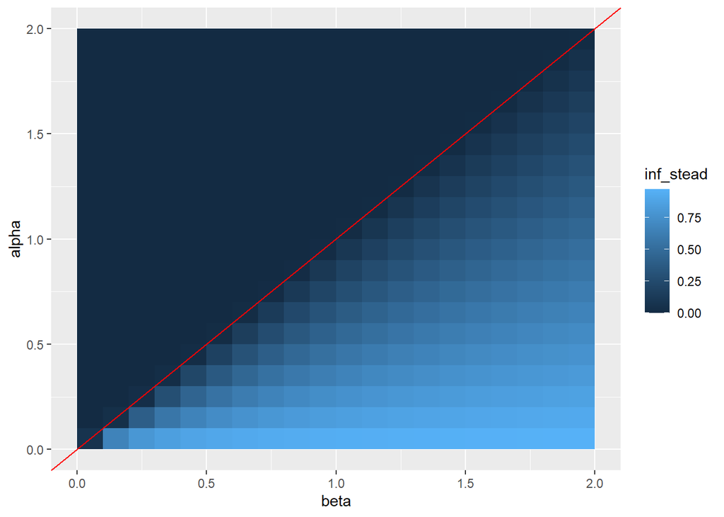

```r
get_final_state <- function(a, b) {
  res <- ode(
    y = c(I = 0.1),
    times = 0:100,
    func = SIS_system,
    parms = c(alpha = a, beta = b)
  )

  res[nrow(res), 'I']
}

## generate all pairs of parameters
param_grid <- expand.grid(alpha = seq(.05, 2, .1), beta = seq(.05, 2, .1))

## for each pair, run SIS and save the final state
inf_stead <- double(nrow(param_grid))
for(i in 1:nrow(param_grid)) {
  inf_stead[i] <- get_final_state(param_grid[i, 1], param_grid[i, 2])
}

gg_heat <- param_grid |>
  as_tibble() |>
  mutate(inf_stead = inf_stead) |>
  ggplot(aes(beta, alpha, fill = inf_stead)) +
  geom_tile() +
  geom_abline(slope=1, intercept=0, col = 'red') # R0 has a func of beta

gg_heat
```

The blank space around the heatmap can be removed with scales:

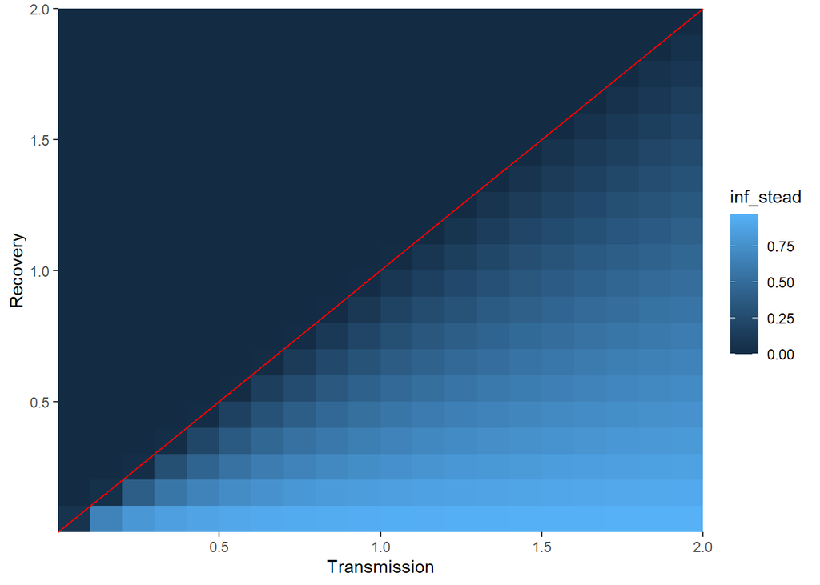

```r
gg_heat +
  scale_x_continuous(expand=expansion(mult=c(0, 0)), name = 'Transmission') +
  scale_y_continuous(expand=expansion(mult=c(0, 0)), name = 'Recovery')
```